# Loan Default Prediction Report

**Rohan Tucker**: **Advanced Machine Learning**:

```r
# Suppress dplyr summarise grouping warning messages
options(dplyr.summarise.inform = FALSE)

## Add R libraries here
library(tidyverse)
library(tidymodels)


# Load data
loans_df <- read_rds("loan_data.rds")
glimpse(loans_df)
```

```
## Rows: 4,110
## Columns: 16
## $ loan_default         <fct> yes, yes, no, yes, no, yes, yes, no, no, no, no, …
## $ loan_amount          <int> 35000, 10000, 28800, 4475, 3600, 12800, 35000, 26…
## $ installment          <dbl> 927.29, 259.58, 941.65, 164.99, 110.70, 389.10, 9…
## $ interest_rate        <dbl> 17.25, 11.50, 8.97, 10.00, 9.72, 20.00, 18.25, 11…
## $ loan_purpose         <fct> small_business, small_business, debt_consolidatio…
## $ application_type     <fct> individual, individual, individual, individual, i…
## $ term                 <fct> five_year, five_year, three_year, three_year, thr…
## $ homeownership        <fct> rent, mortgage, rent, rent, mortgage, rent, mortg…
## $ annual_income        <dbl> 104660, 57000, 160000, 37000, 72000, 73000, 16700…
## $ current_job_years    <dbl> 2, 10, 10, 1, 4, 10, 0, 5, 4, 3, 10, 10, 5, 10, 1…
## $ debt_to_income       <dbl> 29.41, 23.79, 5.96, 13.82, 22.68, 30.94, 25.91, 7…
## $ total_credit_lines   <int> 27, 14, 35, 7, 35, 57, 34, 24, 12, 12, 16, 9, 17,…
## $ years_credit_history <dbl> 15, 4, 17, 5, 11, 14, 22, 16, 9, 12, 22, 9, 8, 17…
## $ missed_payment_2_yr  <fct> no, no, no, no, no, no, no, no, no, no, no, no, n…
## $ history_bankruptcy   <fct> no, no, yes, no, no, no, no, no, no, no, no, no, …
## $ history_tax_liens    <fct> no, no, no, no, no, no, no, no, no, no, no, no, n…
```

# Data Analysis [30 Points]

In this section, you must think of at least 6 relevant questions that explore the relationship between `loan_default` and the other variables in the `loan_df` data set. The goal of your analysis should be discovering which variables drive the differences between customers who do and do not default on their loans.

You must answer each question and provide supporting data summaries with either a summary data frame (using `dplyr`/`tidyr`) or a plot (using `ggplot`) or both.

In total, you must have a minimum of 3 plots (created with `ggplot`) and 3 summary data frames (created with `dplyr`) for the exploratory data analysis section. Among the plots you produce, you must have at least 3 different types (ex. box plot, bar chart, histogram, scatter plot, etc…)

See the example question below.

**Note**: To add an R code chunk to any section of your project, you can use the keyboard shortcut `Ctrl` + `Alt` + `i` or the `insert` button at the top of your R project template notebook file.

## Question 1

**Question**: Are there differences in loan default rates by loan purpose?

**Answer**: Yes, the data indicates that credit card and medical loans have significantly larger default rates than any other type of loan. In fact, both of these loan types have default rates at more than 50%. This is nearly two times the average default rate for all other loan types.

### Summary Table

```r
loans_df %>%
  group_by(loan_purpose) %>%
  summarise(n_customers = n(),
            customers_default = sum(loan_default == 'yes'),
            default_percent = 100 * mean(loan_default == 'yes'))
```

| loan_purpose | n_customers | customers_default | default_percent |
| --- | --- | --- | --- |
| debt_consolidation | 1218 | 308 | 25.28736 |
| credit_card | 879 | 470 | 53.46985 |
| medical | 635 | 384 | 60.47244 |
| small_business | 853 | 221 | 25.90856 |
| home_improvement | 525 | 147 | 28.00000 |

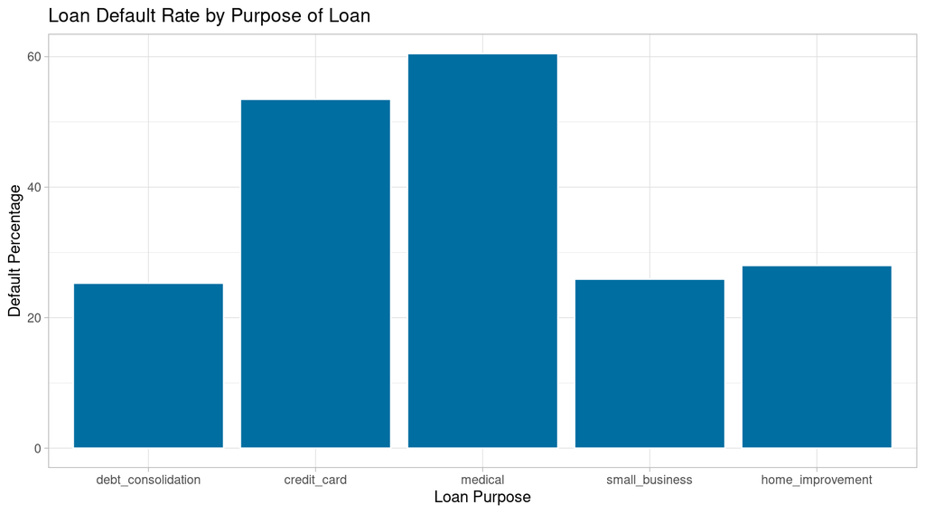

```r
default_rates <- loans_df %>%
                 group_by(loan_purpose) %>%
                 summarise(n_customers = n(),
                 customers_default = sum(loan_default == 'yes'),
                 default_percent = 100 * mean(loan_default == 'yes'))


ggplot(data = default_rates, mapping = aes(x = loan_purpose, y = default_percent)) +
    geom_bar(stat = 'identity', fill = '#006EA1', color = 'white') +
    labs(title = 'Loan Default Rate by Purpose of Loan',
         x = 'Loan Purpose',
         y = 'Default Percentage') +
    theme_light()
```

## Question 2

**Question**: Is there is a relationship between loan amount and loan default status?

```r
loans_df %>%
  group_by(loan_default) %>%
  reframe(customers = n(), average_loan_amount = mean(loan_amount)) %>% knitr::kable()
```

| loan_default | customers | average_loan_amount |
| --- | --- | --- |
| yes | 1530 | 17447.53 |
| no | 2580 | 16245.21 |

```r
t.test(loan_amount ~ loan_default, data = loans_df)
```

```
##
##  Welch Two Sample t-test
##
## data:  loan_amount by loan_default
## t = 3.803, df = 3440.2, p-value = 0.0001455
## alternative hypothesis: true difference in means between group yes and group no is not equal to 0
## 95 percent confidence interval:
##   582.4527 1822.1863
## sample estimates:
## mean in group yes  mean in group no
##          17447.53          16245.21
```

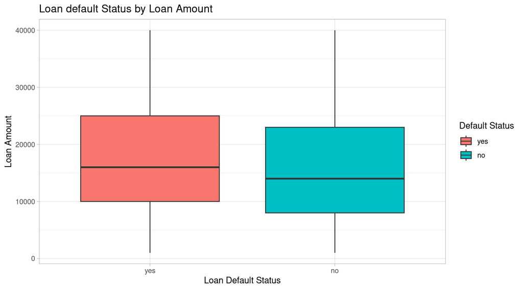

```r
ggplot(loans_df, aes(x = loan_default, y = loan_amount, fill = loan_default))+
  geom_boxplot()+
  labs(x = 'Loan Default Status', y = 'Loan Amount', fill = 'Default Status',
       title = 'Loan default Status by Loan Amount')+
  theme_light()
```

## Question 3

**Question**: How the interest rate is associated with the loan default?

**Answer**: To answer this question, we have create a descriptive summary table, conducted a t-test and visualized a histogram by default status. The descriptive summary shows the customers who defaulted have average interest rate of 14.89% while the non-default customers have lower interest rate of 9.3%. The histogram of interest rate by loan default status shows the individuals who defaulted have higher range of interest rates as compare to the non-default customers. The interest rate range of non-default customer is between 5-15 while the interest rate range of defaulted range between 10 to 20. The t test is significant indicating interest rate is associated with loan default.

```r
loans_df %>%
  group_by(loan_default) %>%
  reframe(customers = n(), average_interest_rate = mean(interest_rate)) %>% knitr::kable()
```

| loan_default | customers | average_interest_rate |
| --- | --- | --- |
| yes | 1530 | 14.892157 |
| no | 2580 | 9.304981 |

```r
t.test(interest_rate ~ loan_default, data = loans_df)
```

```
##
##  Welch Two Sample t-test
##
## data:  interest_rate by loan_default
## t = 59.511, df = 2994.2, p-value < 2.2e-16
## alternative hypothesis: true difference in means between group yes and group no is not equal to 0
## 95 percent confidence interval:
##  5.403091 5.771261
## sample estimates:
## mean in group yes  mean in group no
##         14.892157          9.304981
```

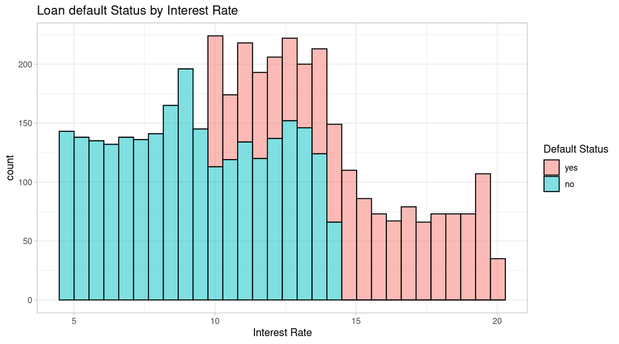

```r
ggplot(loans_df, aes( interest_rate, fill = loan_default))+
  geom_histogram(alpha = 0.5, color = 'black', bins = 30)+
  labs(x = 'Interest Rate', fill = 'Default Status',
       title = 'Loan default Status by Interest Rate')+
  theme_light()
```

## Question 4

**Question**: What is the impact of annual income on the loan default status of a customer?

**Answer**: To answer this question, we have generated a descriptive summary, visualized a boxplot and conducted a t-test. The boxplot shows the customers who defaulted on their loans have lower incomes. Most of their incomes are between 50k and 80k while the non-default customers have higher annual incomes and majority of the customers have incomes greater than 50k and close to 100k. The average annual income summary shows the defaulted customers have average income of 67818.8 while the non-default customers have average annual income of 76096.49 indicating non-default customers have higher annual incomes. The t test is significant indicating the difference between annual income of defaulted and non-default customer is statistical significant.

```r
loans_df %>%
  group_by(loan_default) %>%
  reframe(customers = n(), average_annual_income = mean(annual_income)) %>% knitr::kable()
```

| loan_default | customers | average_annual_income |
| --- | --- | --- |
| yes | 1530 | 67818.80 |
| no | 2580 | 76096.49 |

```r
t.test(annual_income ~ loan_default, data = loans_df)
```

```
##
##  Welch Two Sample t-test
##
## data:  annual_income by loan_default
## t = -7.0931, df = 3438.3, p-value = 1.585e-12
## alternative hypothesis: true difference in means between group yes and group no is not equal to 0
## 95 percent confidence interval:
##  -10565.792  -5989.577
## sample estimates:
## mean in group yes  mean in group no
##          67818.80          76096.49
```

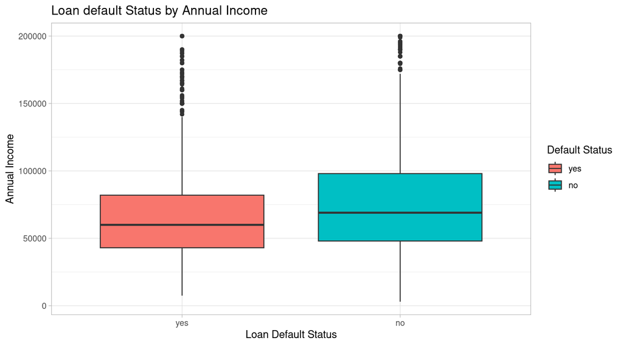

```r
ggplot(loans_df, aes( x =loan_default, y = annual_income, fill = loan_default))+
  geom_boxplot()+
  labs(x = 'Loan Default Status', y = 'Annual Income', fill = 'Default Status',
       title = 'Loan default Status by Annual Income')+
  theme_light()
```

## Question 5

**Question**: How the home ownership status of a customer is associated with loan default?

```r
loans_df %>% group_by(loan_default, homeownership) %>%
  summarise(customers = n()) %>%
  mutate(proportion = customers / sum(customers)) %>%
  ungroup()
```

| loan_default | homeownership | customers | proportion |
| --- | --- | --- | --- |
| yes | mortgage | 628 | 0.4104575 |
| yes | rent | 713 | 0.4660131 |
| yes | own | 189 | 0.1235294 |
| no | mortgage | 1309 | 0.5073643 |
| no | rent | 953 | 0.3693798 |
| no | own | 318 | 0.1232558 |

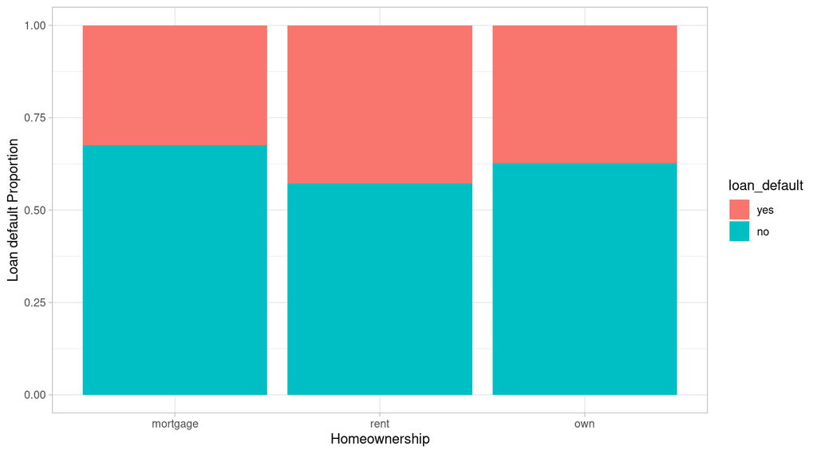

```r
ggplot(loans_df, aes(homeownership, fill = loan_default))+
  geom_bar(position = "fill") +
  labs(x = 'Homeownership', y = 'Loan default Proportion')+
  theme_light()
```

## Question 6

**Question**: How the purpose of loan is associated with the loan default?

```r
loans_df %>% group_by(loan_default, loan_purpose) %>%
  summarise(customers = n()) %>%
  mutate(proportion = customers / sum(customers)) %>%
  ungroup()
```

| loan_default | loan_purpose | customers | proportion |
| --- | --- | --- | --- |
| yes | debt_consolidation | 308 | 0.20130719 |
| yes | credit_card | 470 | 0.30718954 |
| yes | medical | 384 | 0.25098039 |
| yes | small_business | 221 | 0.14444444 |
| yes | home_improvement | 147 | 0.09607843 |
| no | debt_consolidation | 910 | 0.35271318 |
| no | credit_card | 409 | 0.15852713 |
| no | medical | 251 | 0.09728682 |
| no | small_business | 632 | 0.24496124 |
| no | home_improvement | 378 | 0.14651163 |

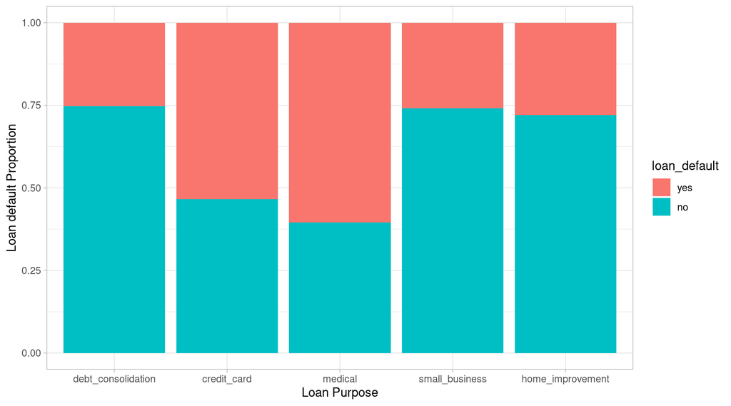

```r
ggplot(loans_df, aes(loan_purpose, fill = loan_default))+
  geom_bar(position = "fill") +
  labs(x = 'Loan Purpose', y = 'Loan default Proportion')+
  theme_light()
```

# Predictive Modeling [70 Points]

In this section of the project, you will fit **three classification algorithms** to predict the response variable,`loan_default`. You should use all of the other variables in the `loans_df` data as predictor variables for each model.

You must follow the machine learning steps below.

The data splitting and feature engineering steps should only be done once so that your models are using the same data and feature engineering steps for training.

- Split the `loans_df` data into a training and test set (remember to set your seed)
- Specify a feature engineering pipeline with the `recipes` package
  - You can include steps such as skewness transformation, dummy variable encoding or any other steps you find appropriate
- Specify a `parsnip` model object
  - You may choose from the following classification algorithms:
    - Logistic Regression
    - LDA
    - QDA
    - KNN
    - Decision Tree
    - Random Forest
- Package your recipe and model into a workflow
- Fit your workflow to the training data
  - If your model has hyperparameters:
    - Split the training data into 5 folds for 5-fold cross validation using `vfold_cv` (remember to set your seed)
    - Perform hyperparamter tuning with a random grid search using the `grid_random()` function
    - Hyperparameter tuning can take a significant amount of computing time. Be careful not to set the `size` argument of `grid_random()` too large. I recommend `size` = 10 or smaller.
    - Select the best model with `select_best()` and finalize your workflow
- Evaluate model performance on the test set by plotting an ROC curve using `autoplot()` and calculating the area under the ROC curve on your test data

## Model 1: KNN

[output not shown]

## Model 2: Decision Tree

```r
tree_model <- decision_tree(cost_complexity = tune(),
                            tree_depth = tune(),min_n = tune()) %>%
  set_engine("rpart") %>%
  set_mode("classification")

tree_workflow <- workflow() %>%
  add_recipe(loan_recipe) %>%
  add_model(tree_model)


tree_grid <- grid_regular(
  cost_complexity(range = c(-5, -1)),
  tree_depth(range = c(1, 10)),
  min_n(range = c(5, 50)),
  levels = 5
)

set.seed(123)
tree_tune_results <- tune_grid(
  tree_workflow,
  resamples = cv_folds,
  grid = tree_grid,
  metrics = metric_set(roc_auc)
)

best_tree <- select_best(tree_tune_results, metric = "roc_auc")
final_tree <- finalize_model(tree_model, best_tree)

tree_final <- workflow() %>%
  add_recipe(loan_recipe) %>%
  add_model(final_tree) %>%
  last_fit(data_split)

tree_results <- tree_final %>% collect_metrics() %>%
  filter(.metric %in% c('accuracy', 'roc_auc')) %>%
  data.frame(Model = c('Decision Tree', 'Decision Tree')) %>%
  select(Model, .metric, .estimate)
tree_results
```

| Model | .metric | .estimate |
| --- | --- | --- |
| Decision Tree | accuracy | 0.8873582 |
| Decision Tree | roc_auc | 0.9580392 |

## Model 3

```r
rf_model <- rand_forest(mtry = tune(), trees = tune()) %>%
  set_engine("randomForest") %>%
  set_mode("classification")


rf_workflow <- workflow() %>%
  add_recipe(loan_recipe) %>%
  add_model(rf_model)


rf_grid <- grid_random(mtry(range = c(1, 10)), trees(range = c(50, 500)), size = 10)

set.seed(123)
rf_tune <- tune_grid(
  rf_workflow,
  resamples = cv_folds,
  grid = rf_grid,
  control = control_grid(save_pred = TRUE)
)

best_rf <- select_best(rf_tune, metric = "roc_auc")
final_rf <- finalize_model(rf_model, best_rf)

rf_final <- workflow() %>%
  add_recipe(loan_recipe) %>%
  add_model(final_rf) %>%
  last_fit(data_split)

rf_results <- rf_final %>% collect_metrics() %>%
  filter(.metric %in% c('accuracy', 'roc_auc')) %>%
  data.frame(Model = c('Random Forest', 'Random Forest')) %>%
  select(Model, .metric, .estimate)
rf_results
```

| Model | .metric | .estimate |
| --- | --- | --- |
| Random Forest | accuracy | 0.8946515 |
| Random Forest | roc_auc | 0.9676379 |

## Comparaing performance

```r
knn_results %>% rbind(tree_results, rf_results) %>%
  arrange(desc(.estimate)) %>% knitr::kable()
```

| Model | .metric | .estimate |
| --- | --- | --- |
| Random Forest | roc_auc | 0.9676379 |
| Decision Tree | roc_auc | 0.9580392 |
| Random Forest | accuracy | 0.8946515 |
| Decision Tree | accuracy | 0.8873582 |
| KNN | roc_auc | 0.8867046 |
| KNN | accuracy | 0.8055105 |

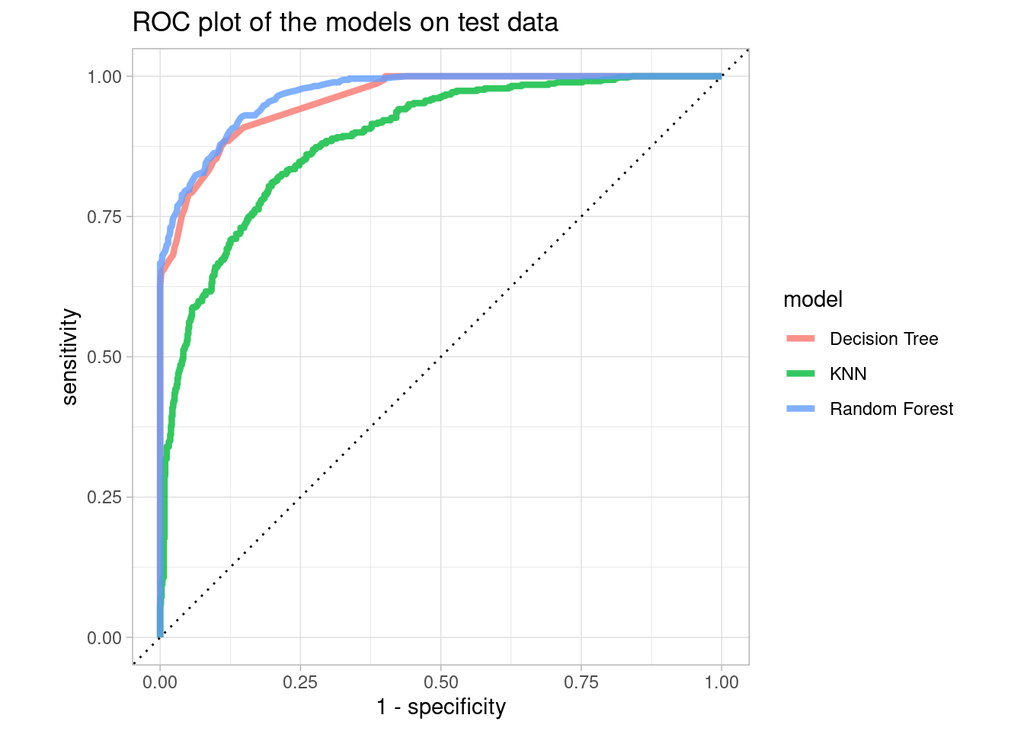

```r
knn_auc <- knn_final %>%
  collect_predictions() %>%
  roc_curve(loan_default, .pred_yes) %>%
  mutate(model = "KNN")

tree_auc <- tree_final %>%
  collect_predictions() %>%
  roc_curve(loan_default, .pred_yes) %>%
  mutate(model = "Decision Tree")

rf_auc <- rf_final %>%
  collect_predictions() %>%
  roc_curve(loan_default, .pred_yes) %>%
  mutate(model = "Random Forest")


bind_rows(knn_auc, tree_auc, rf_auc) %>%
  ggplot(aes(x = 1 - specificity, y = sensitivity, col = model)) +
  geom_path(lwd = 1.5, alpha = 0.8) +
  geom_abline(lty = 3) +
  coord_equal() +
  theme_light()+
  ggtitle('ROC plot of the models on test data')
```

# Summary of Results [50 Points]

Write a summary of your overall findings and recommendations to the executives at the bank. Think of this section as your closing remarks of a presentation, where you summarize your key findings, model performance, and make recommendations to improve loan processes at the bank.

Your executive summary must be written in a business tone, with minimal grammatical errors, and should include the following sections:

## 1. Introduction

In this project, our objective is to help a national bank address a pressing business challenge: identifying and mitigating the risk of loan defaults. The dataset used, `loans_df`, contains detailed information on over 4,000 personal loan customers from the Middle Atlantic and Northeast regions who secured loans in 2017. With increasing rates of loan default in recent years, the bank has been facing significant financial losses, prompting an urgent need to better understand the factors associated with loan default and to identify customers at risk of defaulting. Loan defaults can erode a bank’s profitability, affect cash flow stability, and lead to higher costs in managing non-performing assets. The goal of this analysis is determine the factors such as loan characteristics, borrower financial metrics, or credit history, are most strongly associated with default and to develop machine learning models to predict whether a customer will default on their loan. Evaluating the accuracy of these models will help us assess their reliability in real-world applications. By predicting the likelihood of default, the bank can more effectively prioritize high-risk cases and implement targeted risk management strategies.

## 3. Best Classification Model

The random forest model emerged as the best choice for predicting loan defaults. This model achieved an accuracy of approximately 90% on the test data, which suggests it correctly identifies defaults and non-defaults 90% of the time. Moreover, it resulted highest ROC AUC score of 0.97. The ROC AUC score is especially informative because it ranges from 0 to 1, with a score near 1 signifying near-perfect distinction. In our case, a score of 0.97 implies that the model is very effective at separating high-risk customers from low-risk ones. When visualized, the Random Forest ROC curve is closer to the top-left corner, indicating strong performance. By comparison, the Decision Tree model’s ROC curve was close but slightly lower, and KNN’s curve was noticeably lower, showing it to be the least accurate model for this dataset. For the bank, this means that using the Random Forest model could significantly reduce the risk of lending to high-risk customers while maintaining a high level of accuracy in identifying those who are safe to lend to. This level of accuracy is vital for minimizing defaults, ensuring financial stability, and making more informed lending decisions.

## 5. Conclusion

To address these insights, we implemented and evaluated three machine learning models—KNN, decision trees, and random forests—to predict loan default. Among these, the random forest model performed best, achieving a high accuracy and AUC-ROC score, indicating its strong predictive power. This model enables the bank to accurately identify high-risk customers, potentially allowing for proactive risk mitigation.

## 6. Appendix/Appendices

```r
# Suppress dplyr summarise grouping warning messages
options(dplyr.summarise.inform = FALSE)

## Add R libraries here
library(tidyverse)
library(tidymodels)


# Load data
loans_df <- read_rds("loan_data.rds")
glimpse(loans_df)

loans_df %>%
  group_by(loan_purpose) %>%
  summarise(n_customers = n(),
            customers_default = sum(loan_default == 'yes'),
            default_percent = 100 * mean(loan_default == 'yes'))

default_rates <- loans_df %>%
                 group_by(loan_purpose) %>%
                 summarise(n_customers = n(),
                 customers_default = sum(loan_default == 'yes'),
                 default_percent = 100 * mean(loan_default == 'yes'))


ggplot(data = default_rates, mapping = aes(x = loan_purpose, y = default_percent)) +
    geom_bar(stat = 'identity', fill = '#006EA1', color = 'white') +
    labs(title = 'Loan Default Rate by Purpose of Loan',
         x = 'Loan Purpose',
         y = 'Default Percentage') +
    theme_light()

loans_df %>%
  group_by(loan_default) %>%
  reframe(customers = n(), average_loan_amount = mean(loan_amount)) %>% knitr::kable()

t.test(loan_amount ~ loan_default, data = loans_df)


ggplot(loans_df, aes(x = loan_default, y = loan_amount, fill = loan_default))+
  geom_boxplot()+
  labs(x = 'Loan Default Status', y = 'Loan Amount', fill = 'Default Status',
       title = 'Loan default Status by Loan Amount')+
  theme_light()

loans_df %>%
  group_by(loan_default) %>%
  reframe(customers = n(), average_interest_rate = mean(interest_rate)) %>% knitr::kable()

t.test(interest_rate ~ loan_default, data = loans_df)


ggplot(loans_df, aes( interest_rate, fill = loan_default))+
  geom_histogram(alpha = 0.5, color = 'black', bins = 30)+
  labs(x = 'Interest Rate', fill = 'Default Status',
       title = 'Loan default Status by Interest Rate')+
  theme_light()

loans_df %>%
  group_by(loan_default) %>%
  reframe(customers = n(), average_annual_income = mean(annual_income)) %>% knitr::kable()

t.test(annual_income ~ loan_default, data = loans_df)


ggplot(loans_df, aes( x =loan_default, y = annual_income, fill = loan_default))+
  geom_boxplot()+
  labs(x = 'Loan Default Status', y = 'Annual Income', fill = 'Default Status',
       title = 'Loan default Status by Annual Income')+
  theme_light()

loans_df %>% group_by(loan_default, homeownership) %>%
  summarise(customers = n()) %>%
  mutate(proportion = customers / sum(customers)) %>%
  ungroup()


ggplot(loans_df, aes(homeownership, fill = loan_default))+
  geom_bar(position = "fill") +
  labs(x = 'Homeownership', y = 'Loan default Proportion')+
  theme_light()


loans_df %>% group_by(loan_default, loan_purpose) %>%
  summarise(customers = n()) %>%
  mutate(proportion = customers / sum(customers)) %>%
  ungroup()


ggplot(loans_df, aes(loan_purpose, fill = loan_default))+
  geom_bar(position = "fill") +
  labs(x = 'Loan Purpose', y = 'Loan default Proportion')+
  theme_light()


set.seed(123)
data_split <- initial_split(loans_df, prop = 0.7, strata = 'loan_default')
train_data <- training(data_split)
test_data <- testing(data_split)


loan_recipe <- recipe(loan_default ~ ., data = train_data) %>%
  step_zv(all_predictors()) %>%
  step_corr(all_numeric_predictors(), threshold = 0.80) %>%
  step_YeoJohnson(all_numeric_predictors()) %>%
  step_dummy(all_nominal(), -all_outcomes())


knn_model <- nearest_neighbor(neighbors = tune()) %>%
  set_engine("kknn") %>%
  set_mode("classification")


knn_workflow <- workflow() %>%
  add_recipe(loan_recipe) %>%
  add_model(knn_model)


set.seed(123)
cv_folds <- vfold_cv(train_data, v = 5)

knn_grid <- grid_regular(neighbors(range = c(1, 20)), levels = 10)


set.seed(123)
knn_tune <- tune_grid(
  knn_workflow,
  resamples = cv_folds,
  grid = knn_grid,
  control = control_grid(save_pred = TRUE)
)

best_knn <- select_best(knn_tune, metric = "roc_auc")


final_knn <- finalize_model(knn_model, best_knn)

knn_final <- workflow() %>%
  add_recipe(loan_recipe) %>%
  add_model(final_knn) %>%
  last_fit(data_split)

knn_results <- knn_final %>% collect_metrics() %>%
  filter(.metric %in% c('accuracy', 'roc_auc')) %>%
  data.frame(Model = c('KNN', 'KNN')) %>%
  select(Model, .metric, .estimate)

knn_results

tree_model <- decision_tree(cost_complexity = tune(),
                            tree_depth = tune(),min_n = tune()) %>%
  set_engine("rpart") %>%
  set_mode("classification")

tree_workflow <- workflow() %>%
  add_recipe(loan_recipe) %>%
  add_model(tree_model)


tree_grid <- grid_regular(
  cost_complexity(range = c(-5, -1)),
  tree_depth(range = c(1, 10)),
  min_n(range = c(5, 50)),
  levels = 5
)

set.seed(123)
tree_tune_results <- tune_grid(
  tree_workflow,
  resamples = cv_folds,
  grid = tree_grid,
  metrics = metric_set(roc_auc)
)

best_tree <- select_best(tree_tune_results, metric = "roc_auc")
final_tree <- finalize_model(tree_model, best_tree)

tree_final <- workflow() %>%
  add_recipe(loan_recipe) %>%
  add_model(final_tree) %>%
  last_fit(data_split)

tree_results <- tree_final %>% collect_metrics() %>%
  filter(.metric %in% c('accuracy', 'roc_auc')) %>%
  data.frame(Model = c('Decision Tree', 'Decision Tree')) %>%
  select(Model, .metric, .estimate)
tree_results

rf_model <- rand_forest(mtry = tune(), trees = tune()) %>%
  set_engine("randomForest") %>%
  set_mode("classification")


rf_workflow <- workflow() %>%
  add_recipe(loan_recipe) %>%
  add_model(rf_model)


rf_grid <- grid_random(mtry(range = c(1, 10)), trees(range = c(50, 500)), size = 10)

set.seed(123)
rf_tune <- tune_grid(
  rf_workflow,
  resamples = cv_folds,
  grid = rf_grid,
  control = control_grid(save_pred = TRUE)
)

best_rf <- select_best(rf_tune, metric = "roc_auc")
final_rf <- finalize_model(rf_model, best_rf)

rf_final <- workflow() %>%
  add_recipe(loan_recipe) %>%
  add_model(final_rf) %>%
  last_fit(data_split)

rf_results <- rf_final %>% collect_metrics() %>%
  filter(.metric %in% c('accuracy', 'roc_auc')) %>%
  data.frame(Model = c('Random Forest', 'Random Forest')) %>%
  select(Model, .metric, .estimate)
rf_results

knn_results %>% rbind(tree_results, rf_results) %>%
  arrange(desc(.estimate)) %>% knitr::kable()

knn_auc <- knn_final %>%
  collect_predictions() %>%
  roc_curve(loan_default, .pred_yes) %>%
  mutate(model = "KNN")

tree_auc <- tree_final %>%
  collect_predictions() %>%
  roc_curve(loan_default, .pred_yes) %>%
  mutate(model = "Decision Tree")

rf_auc <- rf_final %>%
  collect_predictions() %>%
  roc_curve(loan_default, .pred_yes) %>%
  mutate(model = "Random Forest")


bind_rows(knn_auc, tree_auc, rf_auc) %>%
  ggplot(aes(x = 1 - specificity, y = sensitivity, col = model)) +
  geom_path(lwd = 1.5, alpha = 0.8) +
  geom_abline(lty = 3) +
  coord_equal() +
  theme_light()+
  ggtitle('ROC plot of the models on test data')
```

— End of the Project —